# Text Mining Session - R Generation Meetup Group

Douglas Zickuhr

23/04/2019

# Agenda

Firstly, I would like to make clear that this presentation is heavily based on the book Text Mining with R by Julia Silge and David Robinson, all the examples were taken from that book. You can check it online [here](https://www.tidytextmining.com/) for free.

1. Tidy data and Tidy Text data
2. Text “Tokenisation”
3. Data reading with readr
4. Data manipulation with dplyr
5. Joining data with dplyr
6. Plotting with ggplot2
7. Basic sentiment analysis

# Tidy data

Using tidy data principles is a powerful way to make handling data easier and more effective, and this is no less true when it comes to dealing with text. As described by Hadley Wickham (Wickham 2014), tidy data has a specific structure:

- Each variable is a column
- Each observation is a row
- Each type of observational unit is a table

# Tidy text data

We thus define the tidy text format as being a table with one-token-per-row. A token is a meaningful unit of text, such as a word, that we are interested in using for analysis, and tokenization is the process of splitting text into tokens. This one-token-per-row structure is in contrast to the ways text is often stored in current analyses, perhaps as strings or in a document-term matrix. For tidy text mining, the token that is stored in each row is most often a single word, but can also be an n-gram, sentence, or paragraph. In the tidytext package, we provide functionality to tokenize by commonly used units of text like these and convert to a one-term-per-row format.

Tidy data sets allow manipulation with a standard set of “tidy” tools, including popular packages such as dplyr (Wickham and Francois 2016), tidyr (Wickham 2016), ggplot2 (Wickham 2009), and broom (Robinson 2017). By keeping the input and output in tidy tables, users can transition fluidly between these packages. We’ve found these tidy tools extend naturally to many text analyses and explorations.

At the same time, the tidytext package doesn’t expect a user to keep text data in a tidy form at all times during an analysis. The package includes functions to tidy() objects (see the broom package [Robinson et al cited above]) from popular text mining R packages such as tm (Feinerer, Hornik, and Meyer 2008) and quanteda (Benoit and Nulty 2016). This allows, for example, a workflow where importing, filtering, and processing is done using dplyr and other tidy tools, after which the data is converted into a document-term matrix for machine learning applications. The models can then be re-converted into a tidy form for interpretation and visualization with ggplot2.

Let’s get our hands dirt. That’s a sample of Emily Dickinson’s text.

```r
text <- c("Because I could not stop for Death -",
          "He kindly stopped for me -",
          "The Carriage held but just Ourselves -",
          "and Immortality",
          "I could stop the death")

text
```

```
## [1] "Because I could not stop for Death -"
## [2] "He kindly stopped for me -"
## [3] "The Carriage held but just Ourselves -"
## [4] "and Immortality"
## [5] "I could stop the death"
```

At this moment, that text is just a character vector but let’s make it a dataframe or in this case a tibble, through the function `tibble()`. In order to load this function to our R session, we need to import the library `dplyr`. A tibble is a more advanced version of a R dataframe. I encourage you to look up for that. I strongly recommend the book R for Data Science (2014) by Hadley Wickham. That book can be accessed for free [here](https://r4ds.had.co.nz/).

```r
library(dplyr)
text_as_df <- tibble(line = 1:5,
                     text = text)

text_as_df
```

```
## # A tibble: 5 x 2
##    line text
##   <int> <chr>
## 1     1 Because I could not stop for Death -
## 2     2 He kindly stopped for me -
## 3     3 The Carriage held but just Ourselves -
## 4     4 and Immortality
## 5     5 I could stop the death
```

That’s definitely some progress. Now we have our data on a modern dataframe. But notice that this data frame containing text isn’t yet compatible with tidy text analysis, though. We can’t filter out words or count which occur most frequently, since each row is made up of multiple combined words. We need to convert this so that it has **one-token-per-document-per-row**.

But what is a token in this context? *A token is a meaningful unit of text, most often a word, that we are interested in using for further analysis, and tokenization is the process of splitting text into tokens.*

## Converting a sample text to tidy data format

The function `unnest_tokens` from `tidytext` package is the perfect solution for our needs here. It will break every word as a single observation, but keeping the remaining information - in our case here, the line. This process is called **tokenisation**.

```r
library(tidytext)

unnest_tokens(tbl = text_as_df,
              output = word,
              input = text)
```

```
## # A tibble: 25 x 2
##     line word
##    <int> <chr>
##  1     1 because
##  2     1 i
##  3     1 could
##  4     1 not
##  5     1 stop
##  6     1 for
##  7     1 death
##  8     2 he
##  9     2 kindly
## 10     2 stopped
## # … with 15 more rows
```

And voilà, that’s the tidy text data format.

In its essence, `unnest_tokens` just request three parameters. 1. tbl: A dataframe or a tibble that contains text data. 2. output: What’s the name of our outputted token variable? 3. input: What’s the name of our inputted text variable?

After using `unnest_tokens`, we’ve split each row so that there is one token (word) in each row of the new data frame; the default tokenization in `unnest_tokens()` is for single words, as shown here. Please notice that:

- Other columns, such as the line number each word came from, are retained.
- Punctuation has been stripped.
- By default, `unnest_tokens()` converts the tokens to lowercase, which makes them easier to compare or combine with other datasets.

## Dealing with real text data

So far we’ve been dealing with a very simple sample of data, what is good for us to have our heads around some concepts of text mining but let’s starting have a look at a real text file. For that, let’s use text of Jane Austen’s six published novels. The concept is the same from the previous exercise, but this time, we won’t create the data but rather import it from a CSV file. This data was exported from `janeaustenr` package developed by Julia Silge.

```r
library(readr)

jane <- read_csv(file = "data/janeausten.csv")

jane
```

```
## # A tibble: 62,279 x 4
##    text                                     book         linenumber chapter
##    <chr>                                    <chr>             <dbl>   <dbl>
##  1 SENSE AND SENSIBILITY                    Sense & Sen…          1       0
##  2 by Jane Austen                           Sense & Sen…          2       0
##  3 (1811)                                   Sense & Sen…          3       0
##  4 CHAPTER 1                                Sense & Sen…          4       1
##  5 The family of Dashwood had long been se… Sense & Sen…          5       1
##  6 was large, and their residence was at N… Sense & Sen…          6       1
##  7 their property, where, for many generat… Sense & Sen…          7       1
##  8 respectable a manner as to engage the g… Sense & Sen…          8       1
##  9 surrounding acquaintance.  The late own… Sense & Sen…          9       1
## 10 man, who lived to a very advanced age, … Sense & Sen…         10       1
## # … with 62,269 more rows
```

To work with this as a tidy dataset, we need to restructure it in the one-token-per-row format, which as we saw earlier is done with the `unnest_tokens()` function. This time I will be using the `%>%` (pipe) operator, as it makes the code way less repetitive and allow us to create a longer workflow with a dataset without the need of several objects cration. I encourage you to learn more about on the book R for Data Science by Hadley Wickham (2014). That book can be accessed for free [here](https://r4ds.had.co.nz/).

```r
jane_tidy <- jane %>%
  unnest_tokens(word,text)

jane_tidy
```

```
## # A tibble: 725,055 x 4
##    book                linenumber chapter word
##    <chr>                    <dbl>   <dbl> <chr>
##  1 Sense & Sensibility          1       0 sense
##  2 Sense & Sensibility          1       0 and
##  3 Sense & Sensibility          1       0 sensibility
##  4 Sense & Sensibility          2       0 by
##  5 Sense & Sensibility          2       0 jane
##  6 Sense & Sensibility          2       0 austen
##  7 Sense & Sensibility          3       0 1811
##  8 Sense & Sensibility          4       1 chapter
##  9 Sense & Sensibility          4       1 1
## 10 Sense & Sensibility          5       1 the
## # … with 725,045 more rows
```

The resulted dataset has over (!!!) 700k rows.

Let’s have a look at the number of words for each book. For that, we are going to use some functions from `dplyr` package and the `%>%` operator.

```r
jane_tidy %>%
  group_by(book) %>%
  summarise(n = n()) %>%
  arrange(desc(n))
```

```
## # A tibble: 6 x 2
##   book                     n
##   <chr>                <int>
## 1 Emma                160996
## 2 Mansfield Park      160460
## 3 Pride & Prejudice   122204
## 4 Sense & Sensibility 119957
## 5 Persuasion           83658
## 6 Northanger Abbey     77780
```

For those who feel more confortable with `SQL`, here goes a transalation of what we’ve done on the chunk above.

```sql
SELECT
book,
count(*) as n
FROM jane_tidy
GROUP BY book
ORDER BY n desc
```

Emma seems to be the longest book with 160k words whilst Northanger Abbey is the shortest, having nearly 78k words.

## Removing Stop words

Now that the data is in one-word-per-row format, we can manipulate it with tidy tools like `dplyr`. Often in text analysis, we will want to remove stop words; stop words are words that are not useful for an analysis, typically extremely common words such as “the”, “of”, “to”, and so forth in English. We can remove stop words (kept in the tidytext dataset `stop_words`) with an `anti_join()`.

The anti-join functions is an implementation of a filtering join, which drops all observations in `x` that have a match in `y`.

```r
jane_tidy_words <- jane_tidy %>%
  anti_join(stop_words)

jane_tidy_words
```

```
## # A tibble: 217,609 x 4
##    book                linenumber chapter word
##    <chr>                    <dbl>   <dbl> <chr>
##  1 Sense & Sensibility          1       0 sense
##  2 Sense & Sensibility          1       0 sensibility
##  3 Sense & Sensibility          2       0 jane
##  4 Sense & Sensibility          2       0 austen
##  5 Sense & Sensibility          3       0 1811
##  6 Sense & Sensibility          4       1 chapter
##  7 Sense & Sensibility          4       1 1
##  8 Sense & Sensibility          5       1 family
##  9 Sense & Sensibility          5       1 dashwood
## 10 Sense & Sensibility          5       1 settled
## # … with 217,599 more rows
```

Please notice that now words like “and”, “the” and “by” are not present on the dataset anymore. It allow us to dive into the context of the text, ignoring words that are not very useful for our analysis here. You can see and manipulate words that are on the `stop_words` dataset just using `dplyr` functions as we’ve been doing but rememeber that every time you load the `tidytext` library, the dataset is reloaded.

```r
jane_tidy_words %>%
  group_by(book) %>%
  summarise(n = n()) %>%
  arrange(desc(n))
```

```
## # A tibble: 6 x 2
##   book                    n
##   <chr>               <int>
## 1 Mansfield Park      47968
## 2 Emma                46775
## 3 Pride & Prejudice   37246
## 4 Sense & Sensibility 36330
## 5 Persuasion          25488
## 6 Northanger Abbey    23802
```

# Word frequencies

Let’s do the word count now, but focusing on a single book and counting words by chapter. We can do that simply by applying the `dplyr` function `filter()`.

```r
jane_tidy_words %>%
  filter(book == "Emma") %>%
  group_by(chapter) %>%
  summarise(n = n()) %>%
  arrange(desc(n))
```

```
## # A tibble: 56 x 2
##    chapter     n
##      <dbl> <int>
##  1      26  1843
##  2      42  1618
##  3       9  1361
##  4      38  1346
##  5      47  1263
##  6       8  1193
##  7      32  1116
##  8      50  1083
##  9      21  1072
## 10      54  1050
## # … with 46 more rows
```

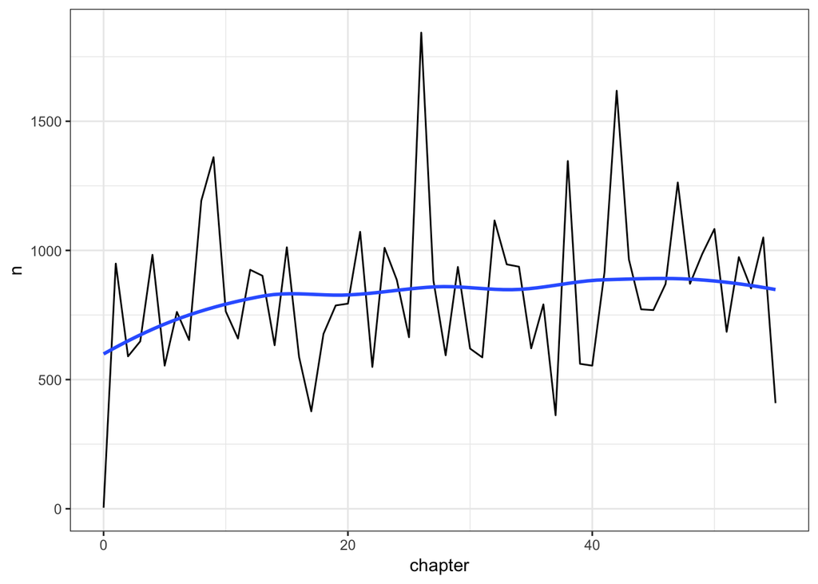

```r
library(ggplot2)

jane_tidy_words %>%
  filter(book == "Emma") %>%
  group_by(chapter) %>%
  summarise(n = n()) %>%
  ggplot(aes(chapter,n)) +
  geom_line() +
  geom_smooth(se=FALSE)
```

We can even count the words and plot them using `ggplot`. It would give us a visual for the most common words.

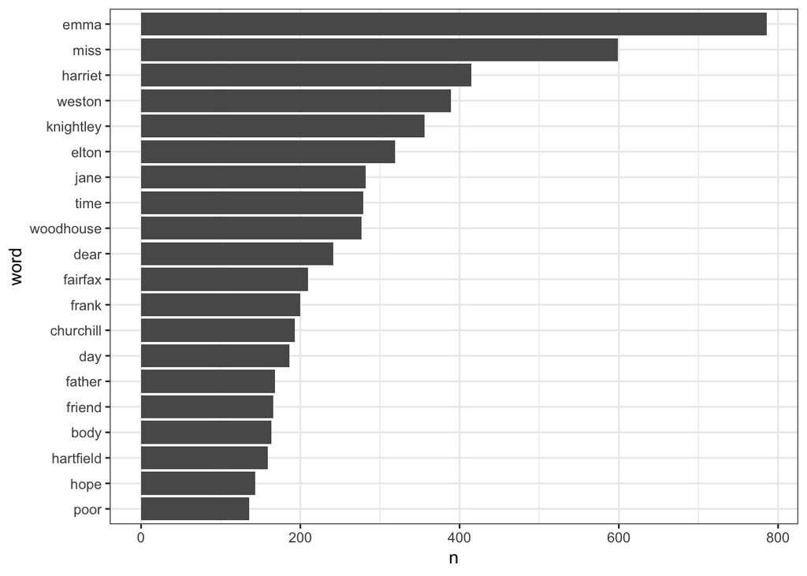

```r
library(ggplot2)
library(forcats)

jane_tidy_words %>%
  filter(book == "Emma") %>%
  group_by(word) %>%
  summarise(n = n()) %>%
  arrange(desc(n)) %>%
  top_n(20,wt = n) %>%
  mutate(word = fct_reorder(word,n)) %>%
  ggplot(aes(word, n)) +
  geom_col() +
  coord_flip()
```

What if we compare the top 10 words among Jane Austen’s novels? I bet we will see loads of names on it.

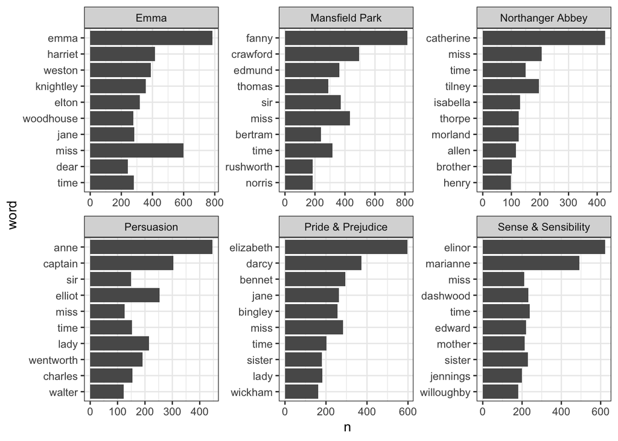

```r
jane_tidy_words %>%
  group_by(book,word) %>%
  summarise(n = n()) %>%
  top_n(10) %>%
  ungroup() %>%
  mutate(word = fct_reorder(word,n)) %>%
  ggplot(aes(word, n)) +
  geom_col() +
  coord_flip() +
  facet_wrap(~book, scales = "free")
```

And that’s definitely it - People names all around. Emma, Edmuns, Thomas, Catherine, etc. The same approach may be used to compare top words between chapters of a book for instance.

## Wordclouds

On a side note, let’s do a wordcloud. They are so nice to visualise words.

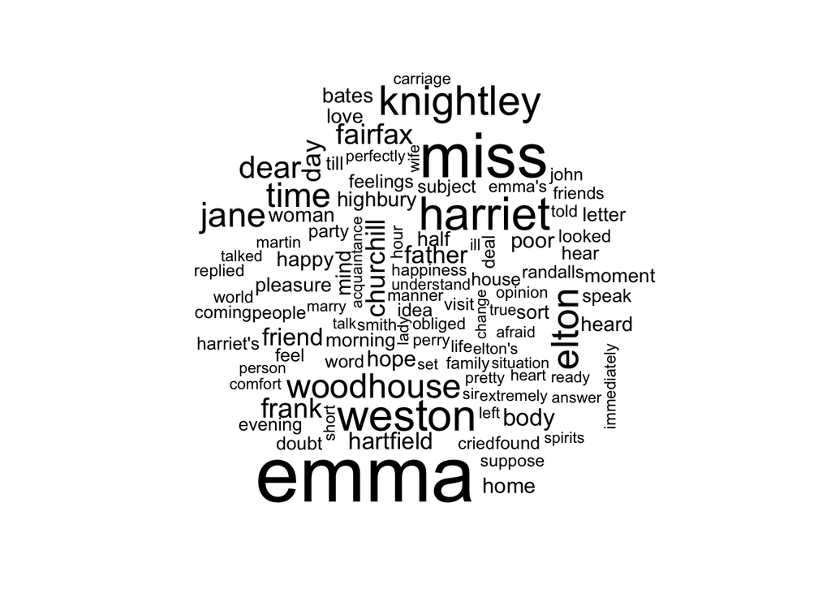

```r
library(wordcloud)

set.seed(123)
jane_tidy_words %>%
  filter(book == "Emma") %>%
  count(word) %>%
  with(wordcloud(word, n, max.word = 100))
```

# Sentiment Analysis

In the previous section, we explored what we mean by the tidy text format and showed how this format can be used to approach questions about word frequency. This allowed us to analyze which words are used most frequently in documents and to compare documents, but now let’s investigate a different topic. Let’s address the topic of opinion mining or sentiment analysis. When human readers approach a text, we use our understanding of the emotional intent of words to infer whether a section of text is positive or negative, or perhaps characterized by some other more nuanced emotion like surprise or disgust. We can use the tools of text mining to approach the emotional content of text programmatically, as shown in the following flowchart.

[figure not shown]

One way to analyze the sentiment of a text is to consider the text as a combination of its individual words and the sentiment content of the whole text as the sum of the sentiment content of the individual words. This isn’t the only way to approach sentiment analysis, but it is an often-used approach, and an approach that naturally takes advantage of the tidy tool ecosystem.

## Lexicons

```r
library(tidytext)
sentiments
```

```
## # A tibble: 27,314 x 4
##    word        sentiment lexicon score
##    <chr>       <chr>     <chr>   <int>
##  1 abacus      trust     nrc        NA
##  2 abandon     fear      nrc        NA
##  3 abandon     negative  nrc        NA
##  4 abandon     sadness   nrc        NA
##  5 abandoned   anger     nrc        NA
##  6 abandoned   fear      nrc        NA
##  7 abandoned   negative  nrc        NA
##  8 abandoned   sadness   nrc        NA
##  9 abandonment anger     nrc        NA
## 10 abandonment fear      nrc        NA
## # … with 27,304 more rows
```

The three general-purpose lexicons are:

- `AFINN` from [Finn Årup Nielsen](http://www2.imm.dtu.dk/pubdb/views/publication_details.php?id=6010)
- `bing` from [Bing Liu and collaborators](https://www.cs.uic.edu/~liub/FBS/sentiment-analysis.html)
- `nrc` from [Saif Mohammad and Peter Turney](http://saifmohammad.com/WebPages/NRC-Emotion-Lexicon.htm)

All three of these lexicons are based on unigrams, i.e., single words. These lexicons contain many English words and the words are assigned scores for positive/negative sentiment, and also possibly emotions like joy, anger, sadness, and so forth. The `nrc` lexicon categorizes words in a binary fashion (“yes”/“no”) into categories of positive, negative, anger, anticipation, disgust, fear, joy, sadness, surprise, and trust. The `bing` lexicon categorizes words in a binary fashion into positive and negative categories. The `AFINN` lexicon assigns words with a score that runs between -5 and 5, with negative scores indicating negative sentiment and positive scores indicating positive sentiment. All of this information is tabulated in the sentiments dataset, and tidytext provides a function `get_sentiments()` to get specific sentiment lexicons without the columns that are not used in that lexicon.

For instance, let’s check `AFINN` lexicon.

```r
get_sentiments("afinn")
```

```
## # A tibble: 2,476 x 2
##    word       score
##    <chr>      <int>
##  1 abandon       -2
##  2 abandoned     -2
##  3 abandons      -2
##  4 abducted      -2
##  5 abduction     -2
##  6 abductions    -2
##  7 abhor         -3
##  8 abhorred      -3
##  9 abhorrent     -3
## 10 abhors        -3
## # … with 2,466 more rows
```

On the other hand, `bing` dataset has just positive or negative sentiments by words.

```r
get_sentiments("bing")
```

```
## # A tibble: 6,788 x 2
##    word        sentiment
##    <chr>       <chr>
##  1 2-faced     negative
##  2 2-faces     negative
##  3 a+          positive
##  4 abnormal    negative
##  5 abolish     negative
##  6 abominable  negative
##  7 abominably  negative
##  8 abominate   negative
##  9 abomination negative
## 10 abort       negative
## # … with 6,778 more rows
```

Finally, the `nrc` lexicon categorise words for sentiments. It means that a single word could be related to one or more sentiments.

```r
get_sentiments("nrc")
```

```
## # A tibble: 13,901 x 2
##    word        sentiment
##    <chr>       <chr>
##  1 abacus      trust
##  2 abandon     fear
##  3 abandon     negative
##  4 abandon     sadness
##  5 abandoned   anger
##  6 abandoned   fear
##  7 abandoned   negative
##  8 abandoned   sadness
##  9 abandonment anger
## 10 abandonment fear
## # … with 13,891 more rows
```

That what happens with the word abandoned, for example. That word is related to three sentiments: anger, fear and sadness. It is also related to a general negative sentiment.

## Sentiment analysis with inner join

Well, let’s do some sentiment analysis now using `nrc` lexicon first. We could try to identify chapters that have more words that are related to the feeling of joy. We will analyse how “joy words” are spread across Emma and Pride & Prejudice chapters.

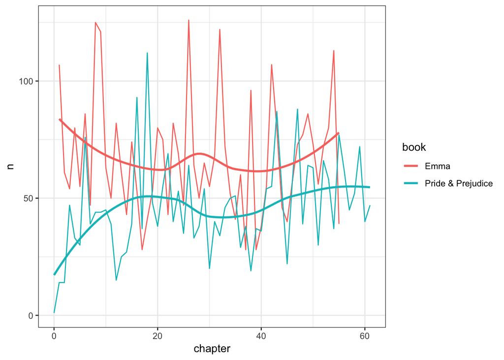

```r
nrc_joy <- get_sentiments("nrc") %>%
  filter(sentiment == "joy")

jane_tidy_words %>%
  filter(book %in% c("Emma","Pride & Prejudice")) %>%
  inner_join(nrc_joy) %>%
  group_by(book,chapter) %>%
  summarise(n = n()) %>%
  ggplot(aes(x=chapter,y=n,group=book,colour=book)) +
  geom_line() +
  geom_smooth(se = FALSE)
```

The plot shows us that both novels have different behaviours. While Emma starts happier, Pride & Prejudice starts unhappier. Curiously they have almost mirror effect. One thing that we could consider is that Emma has much more words than Pride & Preducie, as we see at the word couting. We can make it fairer by comparing “joy words” with the total number of words, creating then a “joy rate” by chapter.

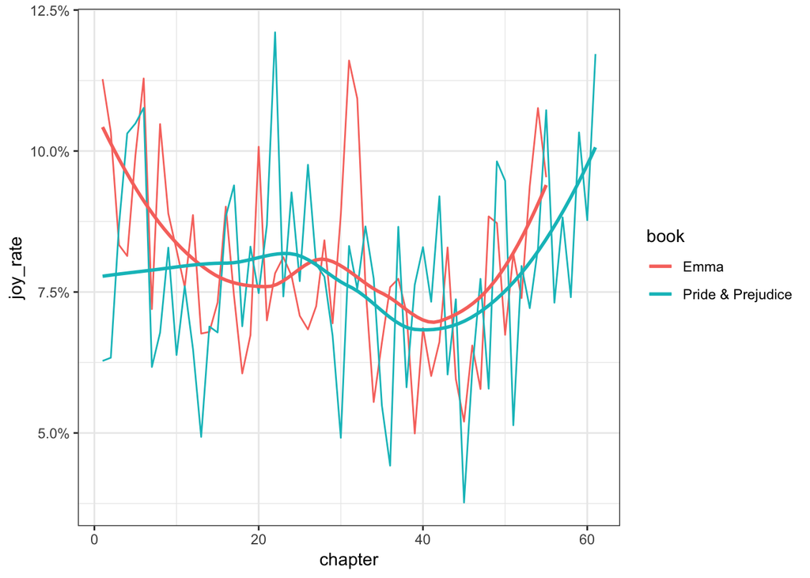

```r
jane_tidy_words %>%
  filter(book %in% c("Emma","Pride & Prejudice"),
         chapter > 0) %>%
  group_by(book,chapter) %>%
  mutate(words = n()) %>%
  inner_join(nrc_joy) %>%
  group_by(book,chapter,words) %>%
  summarise(joy_words = n()) %>%
  mutate(joy_rate = joy_words/words) %>%
  ggplot(aes(x=chapter,y=joy_rate,group=book,colour=book)) +
  geom_line() +
  geom_smooth(se = FALSE) +
  scale_y_continuous(labels = scales::percent_format(accuracy = 0.5))
```

Finally, let’s analyse the same books but now utilising the afinn lexicon, which give us a score for each word, from -5 (bad) to 5 (good).

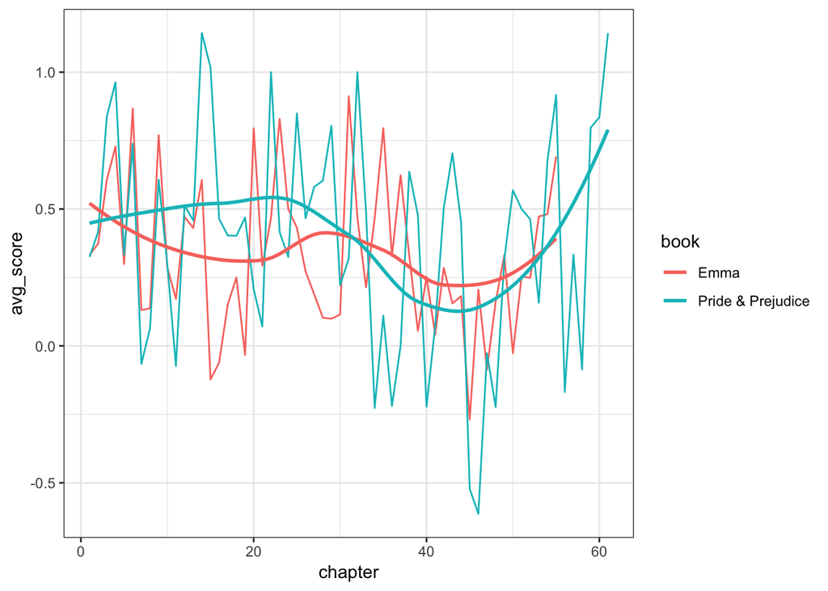

```r
afinn_sentiments <- get_sentiments("afinn")

jane_tidy_words %>%
  filter(book %in% c("Emma","Pride & Prejudice"),
         chapter > 0) %>%
  inner_join(afinn_sentiments) %>%
  group_by(book, chapter) %>%
  summarise(avg_score = mean(score)) %>%
  ggplot(aes(chapter,avg_score,group=book,colour = book)) +
  geom_line() +
  geom_smooth(se = FALSE)
```

It looks like the results are not very different from the previous analysis.

# And what’s next?

There are still many other techniques we could use to apply text mining analysis, such as:

- TF-IDF - Term Frequency Inverse Term Frequency
- N-grams
- Casting data from and to tidy text formats
- Topic Modelling - LDA
- Advanced topics like NLP - Google NLP & Amazon Comprehend